# Time Series Analysis

Nirzaree

23/10/2020

## Theory

```
Stationary timeseries:
1. Mean of series is constant and does not vary with time.
2. Variance is constant (homoscedasticity)
3. Covariance is constant (seasonality effect is minimal)
=> Should look like random white noise irrespective of observed time interval.

Stationary testing and converting a timeseries into a stationary series is crucial for any time series analysis.

Ref:
https://www.analyticsvidhya.com/blog/2015/12/complete-tutorial-time-series-modeling/
http://r-statistics.co/Time-Series-Analysis-With-R.html
https://boostedml.com/2020/05/visualizing-time-series-in-r.html
http://people.cs.pitt.edu/~milos/courses/cs3750/lectures/class16.pdf
```

## AirPassengers

### Explore dataset

```r
data("AirPassengers")
class(AirPassengers)
```

```
## [1] "ts"
```

```r
start(AirPassengers)
```

```
## [1] 1949    1
```

```r
end(AirPassengers)
```

```
## [1] 1960   12
```

```r
frequency(AirPassengers)
```

```
## [1] 12
```

```r
summary(AirPassengers)
```

```
##    Min. 1st Qu.  Median    Mean 3rd Qu.    Max.
##   104.0   180.0   265.5   280.3   360.5   622.0
```

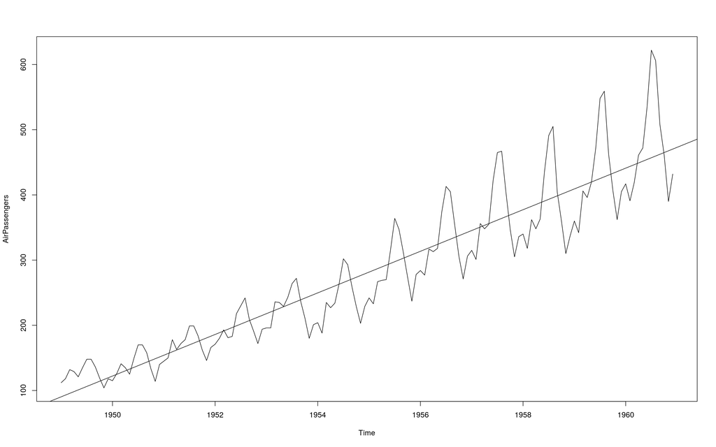

```
## integer(0)
```

```r
plot(AirPassengers) + abline(reg = lm(AirPassengers~time(AirPassengers)))
```

```r
cycle(AirPassengers)
```

```
##      Jan Feb Mar Apr May Jun Jul Aug Sep Oct Nov Dec
## 1949   1   2   3   4   5   6   7   8   9  10  11  12
## 1950   1   2   3   4   5   6   7   8   9  10  11  12
## 1951   1   2   3   4   5   6   7   8   9  10  11  12
## 1952   1   2   3   4   5   6   7   8   9  10  11  12
## 1953   1   2   3   4   5   6   7   8   9  10  11  12
## 1954   1   2   3   4   5   6   7   8   9  10  11  12
## 1955   1   2   3   4   5   6   7   8   9  10  11  12
## 1956   1   2   3   4   5   6   7   8   9  10  11  12
## 1957   1   2   3   4   5   6   7   8   9  10  11  12
## 1958   1   2   3   4   5   6   7   8   9  10  11  12
## 1959   1   2   3   4   5   6   7   8   9  10  11  12
## 1960   1   2   3   4   5   6   7   8   9  10  11  12
```

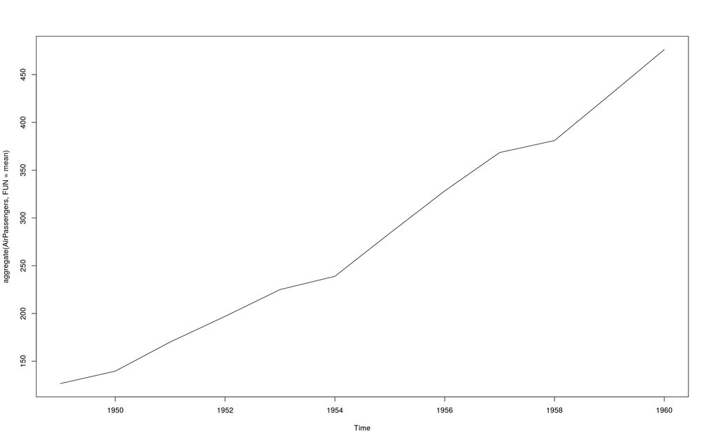

```r
plot(aggregate(AirPassengers,FUN = mean))
```

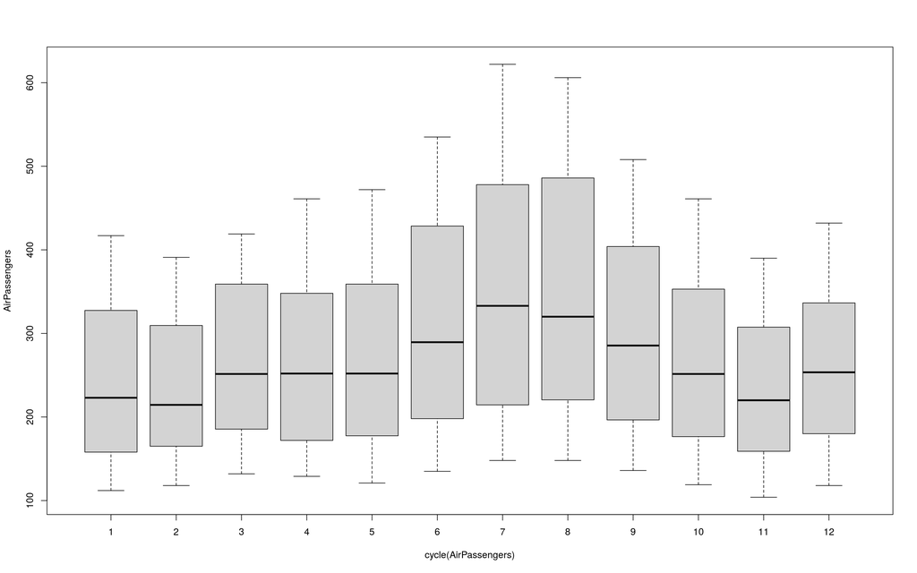

```r
boxplot(AirPassengers~cycle(AirPassengers))
```

**Quick Observations:**

- Trend: Increasing
- Seasonality: Repeated patterns over the years.
- Increasing variance: Swings are increasing over the years.

A time series has 4 components:

1. Trend: Defines the long term behavior
2. Cycles: Define mid term non repeated deviations from trend
3. Seasonality: Defines periodic or repeated fluctuations
4. Noise or remainder: Random fluctuations

In many cases, trend and cycles are combined into one single trend-cycle or trend component. The decomposition of time series is either additive or multiplicative

$$x_t = T_t + S_t + R_t$$
or
$$x_t = T_t * S_t * R_t$$

When to use which formulation: If magnitude of seasonality depends on magnitude of raw values, then multiplicative else additive. In the given dataset, seasonality does depend on the raw values so multiplicative decomposition is more relevant.

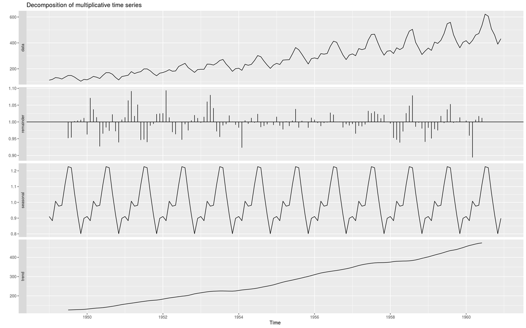

```r
decomposedAP <- decompose(AirPassengers,type = "multiplicative")
autoplot(decomposedAP)
```

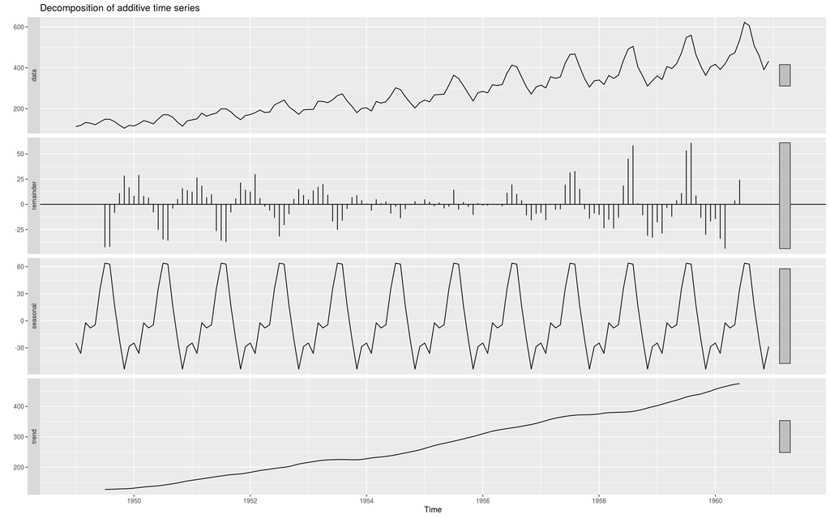

```r
additivedecomposedAP <- decompose(AirPassengers,type = "additive")
autoplot(additivedecomposedAP)
```

**Observations:**

- Trend component is almost linear
- Each year starts with a low, with peak in July - August summer followed by a dip again.
- Random component is not completely random (although I dont see any real pattern, but the [reference](https://boostedml.com/2020/05/visualizing-time-series-in-r.html) says so) (todo: understand this better)

### Stationarity test

- **Augmented Dickey Fuller Test (ADF)**: Most common test to detect stationarity. Here, the null hypothesis is that the series is non-stationary. So if we find that the p-value in the ADF test < significance level (0.05), we reject the null hypothesis.

```r
adf.test(AirPassengers)
```

```
##
##  Augmented Dickey-Fuller Test
##
## data:  AirPassengers
## Dickey-Fuller = -7.3186, Lag order = 5, p-value = 0.01
## alternative hypothesis: stationary
```

```r
kpss.test(AirPassengers)
```

```
##
##  KPSS Test for Level Stationarity
##
## data:  AirPassengers
## KPSS Level = 2.7395, Truncation lag parameter = 4, p-value = 0.01
```

### Stationarize the series:

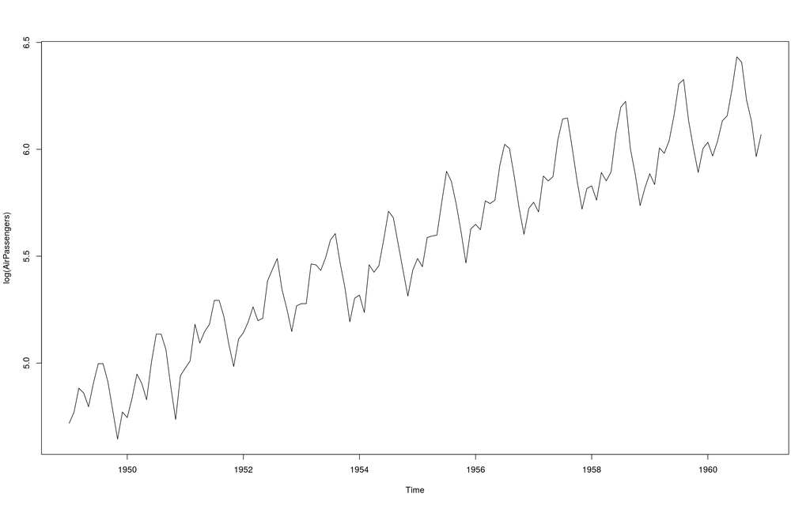

```r
plot(log(AirPassengers))
```

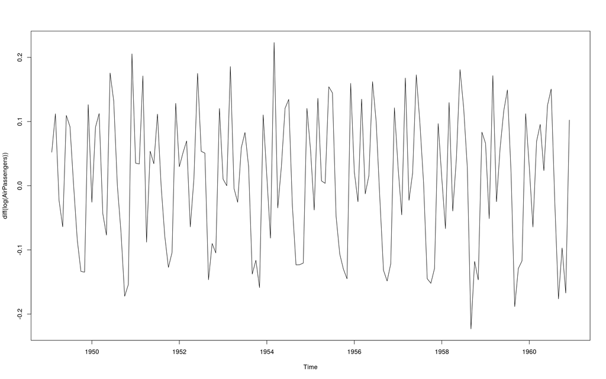

```r
plot(diff(log(AirPassengers)))
```

```r
adf.test(diff(log(AirPassengers)))
```

```
##
##  Augmented Dickey-Fuller Test
##
## data:  diff(log(AirPassengers))
## Dickey-Fuller = -6.4313, Lag order = 5, p-value = 0.01
## alternative hypothesis: stationary
```

### Predict:

Ref and issues:

1. http://people.cs.pitt.edu/~milos/courses/cs3750/lectures/class16.pdf theory only
2. http://r-statistics.co/Time-Series-Analysis-With-R.html No model. no good transformation steps and explanations.
3. https://www.kaggle.com/chirag19/time-series-analysis-with-python-beginner has everything, but dont know how credible + python (not R)
4. https://rpubs.com/neharaut05/TimeSeries_AirPassangerForecast just log(ts) for stationarizing. Not solid.
5. http://rstudio-pubs-static.s3.amazonaws.com/311446_08b00d63cc794e158b1f4763eb70d43a.html No transformation of the series at all
6. https://www.analyticsvidhya.com/blog/2015/12/complete-tutorial-time-series-modeling/ too much of things without really basing the concepts. 3

https://www.kaggle.com/chirag19/air-passengers/notebooks https://www.kaggle.com/chirag19/time-series-analysis-with-python-beginner

https://rpubs.com/neharaut05/TimeSeries_AirPassangerForecast http://rstudio-pubs-static.s3.amazonaws.com/311446_08b00d63cc794e158b1f4763eb70d43a.html